# Rapport

# Questions Théoriques

## T-2

### #2

La fonction réciproque est la suivante: $g(u)=\frac{1}{u}$. Par conséquent, on obtient: $u_{i}=\frac{1}{\beta_{0}+\beta_{1}x_{i1}+x_{i2}}$

#### a)

Dans le cas où $x_{i1}$ augmente de 1, on obtient que Y augmente de:

$$\begin{align*}
E[Y_{i};x_{i1}=x_{i1}^{*}+1]-E[Y_{i};x_{i1}=x_{i1}^{*}] &= \frac{1}{\beta_{0}+\beta_{1}(x_{i1}+1)+x_{i2}} -\frac{1}{\beta_{0}+\beta_{1}x_{i1}+x_{i2}}
\end{align*}$$

#### b)

Dans le cas où $x_{i2}$ augmente de 1, on obtient que Y augmente de:

$$\begin{align*}
E[Y_{i};x_{i2}=x_{i2}^{*}+1]-E[Y_{i};x_{i2}=x_{i2}^{*}] &= \frac{1}{\beta_{0}+\beta_{1}x_{i1}+x_{i2}+1} -\frac{1}{\beta_{0}+\beta_{1}x_{i1}+x_{i2}}
\end{align*}$$

##### c)

On calcule les intervalles de confiance de Wald pour nos $\hat{\beta_{j}}$
$$\begin{align*}
IC(\hat{\beta_{j}},\alpha)&= \hat{\beta_{j}} \pm z_{\alpha/2} \sqrt{\hat{Var(\hat{\beta_{j}})}}\\
IC(\hat{\beta_{0}},0.95)&= 0.1 \pm 1.96 \sqrt{0.000625} =[0.051, 0.149]\\
IC(\hat{\beta_{1}},0.95)&= -0.01 \pm 1.96 \sqrt{0.000016} =[0.01784, -0.00216]
\end{align*}$$

#### d)

L’intervalle de confiance pour notre prédicteur linéaire $\boldsymbol{x}_{0}'\boldsymbol{\hat{\beta}}$ est $\boldsymbol{x}_{0}'\boldsymbol{\hat{\beta}} \pm z_{\alpha/2} \sqrt{v^{2}(\boldsymbol{x}_{0})}$

$$\begin{align*}
v^{2}(\boldsymbol{x}_{0})&= \hat{Var}\left(\sum_{j=0}^{p'}x_{0j}\hat{\beta_{j}}\right)\\
&=\hat{Var}(\hat{\beta_{0}})+ x_{01}^{2}\hat{Var}(\hat{\beta_{1}}) +2x_{01}\hat{Cov}(\hat{\beta_{0}},\hat{\beta_{1}})\\
&=0.000625+5^{2}*0000016+2*5*-0.0001\\
&=0.000025
\end{align*}$$

On obtient donc:

$IC(\boldsymbol{x}_{0}'\boldsymbol{\hat{\beta}},0.95)=0.1-5*0.01+0.5 \pm 1.96\sqrt{0.000025} =[0.5402, 0.5598]$

On peut maintenant trouver notre intervalle de confiance pour $Y_{i}$:

$IC(Y_{i},0.95)=\frac{1}{IC(\boldsymbol{x}_{0}'\boldsymbol{\hat{\beta}},0.95)}=[1.786, 1.851166]$

### #4

##### a)

Selon notre fonction, on obtient:

$$\begin{align*}
\ell(\beta_{0},\beta_{1};Y)&=\sum_{i=1}^{n} ln(f(y_{i}|x_{i};\beta_{0},\beta_{1})) \\
&=\sum_{i=1}^{n} ln(\frac{1}{u_{i}}e^{-\frac{y_{i}}{u_{i}}})\\
&=\sum_{i=1}^{n} ln(\frac{1}{u_{i}})-\frac{y_{i}}{u_{i}} \\
&=\sum_{i=1}^{n} ln(\beta_{0}+\beta_{1}x_{i})-y_{i}(\beta_{0}+\beta_{1}x_{i}) \\
\end{align*}$$

#### b)

On cherche la déviance. On sait que $\ell(u;Y)=\sum_{i=1}^{n} ln(\frac{1}{u_{i}})-\frac{y_{i}}{u_{i}}$

$$\begin{align*}
D(Y,u)&=2(\ell(y;Y)-\ell(u;Y))\\
&=2(\ell(y;Y)-\ell(g^{-1}(\beta_{0}+\beta_{1}x_{i};Y))\\
&=2\left(\sum_{i=1}^{n} ln(\frac{1}{y_{i}})-\frac{y_{i}}{y_{i}}-\sum_{i=1}^{n} ln(\beta_{0}+\beta_{1}x_{i})-y_{i}(\beta_{0}+\beta_{1}x_{i})\right)\\
&=2\left(\sum_{i=1}^{n} ln(\frac{1}{y_{i}})-1-ln(\beta_{0}+\beta_{1}x_{i})+y_{i}(\beta_{0}+\beta_{1}x_{i})\right)
\end{align*}$$

### #5

#### a)

On peut exprimer $u_{i}$ de la façon suivante: $u_{i}=exp\left(\beta_{0}+\beta_{1}x_{i1}+\beta_{2}x_{i2}+ln(v_{i})\right)=e^{\beta_{0}}e^{\beta_{1}x_{i1}}e^{\beta_{2}x_{i2}}v_{i}$. Par conséquent, si on remplace $v_{i}$ par $v_{i}^{*}=1.05v_{i}$, on obtient:

$$\begin{align*}
u_{i}^{*}&=e^{\beta_{0}}e^{\beta_{1}x_{i1}}e^{\beta_{2}x_{i2}}v_{i}^{*}\\
u_{i}^{*}&=e^{\beta_{0}}e^{\beta_{1}x_{i1}}e^{\beta_{2}x_{i2}}v_{i}1.05\\
u_{i}^{*}&=u_{i}*1.05
\end{align*}$$

#### b)

$$\begin{align*}
u_{i}^{*}&=e^{\beta_{0}}e^{0.24(x_{i1}+1)}e^{\beta_{2}x_{i2}}v_{i}\\
u_{i}^{*}&=e^{\beta_{0}}e^{0.24x_{i1}}e^{0.24}e^{\beta_{2}x_{i2}}v_{i}\\
u_{i}^{*}&=u_{i}e^{0.24}\\
u_{i}^{*}&=u_{i}1.27
\end{align*}$$

Lorsque $x_{i1}$ augmente de une unité, alors la moyenne augmente d’environ 27% ($e^{0.24}$).

#### c)

On procède au test d’hypothèse suivant:

$H_{0}$: Le modèle poisson est suffisant

$H_{1}$: Le modèle binomiale négatif est nécessaire

$$\begin{align*}
\epsilon&=D_{0}-D{1}=3.8\\
p&=0.5P(\chi^{2}_{1}>\epsilon)
&=0.5P(\chi^{2}_{1}>3.8)
&=0.02562629
\end{align*}$$

Comme la p-value est inférieure à 0.05, on rejète l’hypothèse $H_{0}$. On doit utiliser le modèle de la négative binomiale.

# P-1

### Analyse de multicolinéarité

Avant de faire notre modèle on peut procéder à une analyse de multicolinéarité en calculant nos facteur d’inflation de la variance (VIF):

```
## # A tibble: 6 x 3
##   Variables Tolerance   VIF
##   <chr>         <dbl> <dbl>
## 1 WT2          0.518   1.93
## 2 HT2          0.304   3.29
## 3 WT9          0.0709 14.1
## 4 HT9          0.277   3.61
## 5 LG9          0.0883 11.3
## 6 ST9          0.675   1.48
```

```
## Tolerance and Variance Inflation Factor
## ---------------------------------------
## # A tibble: 6 x 3
##   Variables Tolerance   VIF
##   <chr>         <dbl> <dbl>
## 1 WT2          0.518   1.93
## 2 HT2          0.304   3.29
## 3 WT9          0.0709 14.1
## 4 HT9          0.277   3.61
## 5 LG9          0.0883 11.3
## 6 ST9          0.675   1.48
##
##
## Eigenvalue and Condition Index
## ------------------------------
##   Eigenvalue Condition Index    intercept        WT2          HT2
## 1 6.96547210           1.000 0.0000048538 0.00014278 0.0000070895
## 2 0.01558744          21.139 0.0024597226 0.00056037 0.0021884104
## 3 0.01068856          25.528 0.0017927623 0.17933042 0.0011040227
## 4 0.00639981          32.991 0.0000885548 0.62817767 0.0000089499
## 5 0.00147774          68.656 0.0162934970 0.00042912 0.0269772209
## 6 0.00025142         166.446 0.0000564458 0.07143476 0.7028342227
## 7 0.00012293         238.041 0.9793041636 0.11992489 0.2668800838
##           WT9          HT9         LG9        ST9
## 1 0.000026084 0.0000082937 0.000008255 0.00029103
## 2 0.009866383 0.0022007833 0.000019912 0.48670716
## 3 0.033968630 0.0011253071 0.000496706 0.37674138
## 4 0.061207422 0.0009060785 0.003410444 0.09996265
## 5 0.051248011 0.0541522718 0.142343281 0.00027082
## 6 0.036956039 0.7594853714 0.006226504 0.00330584
## 7 0.806727430 0.1821218940 0.847494898 0.03272112
```

Avec cette analyse, on réalise qu’il a certains facteurs d’inflation de la variance supérieur à 10 (WT9 et LG9). On peut aussi observer certains indices de conditionnement qui sont calculés à partir des valeurs propres atteignent des valeurs supérieur à 30. Finalement, on constate que les variables WT9 et LG9 sont probablement en multicollinéarité, car leurs dépendances linéaires $p_{lj}$ sont supérieur à 60% pour l’indice de conditionnement le plus élevé (238.041>30).

Pour remédier au problème, on peut retirer la variable LG9:

```
## # A tibble: 5 x 3
##   Variables Tolerance   VIF
##   <chr>         <dbl> <dbl>
## 1 WT2           0.587  1.70
## 2 HT2           0.346  2.89
## 3 WT9           0.409  2.44
## 4 HT9           0.322  3.10
## 5 ST9           0.704  1.42
```

On constate qu’aucun VIF n’est maintenant supérieur à 10. On peut commencer à faire notre modèle avec ces variables.

### Modèle

Puisque qu’on a peu de variables dans nos données ($p'=5$), on peut se permettre de trouver tous les sous-modèles possibles pour ensuite choisir le meilleur:

```
##    mindex          predictors  rsquare      adjr  predrsq     aic
## 17     25         WT2 HT2 HT9 0.085569 -0.039126 -0.32010 104.774
## 29     26     WT2 WT9 HT9 ST9 0.529970  0.440441  0.25032  89.471
## 27     27     WT2 HT2 WT9 ST9 0.463331  0.361109  0.15655  92.918
## 30     28     HT2 WT9 HT9 ST9 0.350771  0.227109 -0.10651  97.868
## 26     29     WT2 HT2 WT9 HT9 0.328191  0.200227 -0.15439  98.757
## 28     30     WT2 HT2 HT9 ST9 0.150409 -0.011417 -0.33771 104.862
## 31     31 WT2 HT2 WT9 HT9 ST9 0.551089  0.438861  0.17547  90.275
```

```
## [1] "Modèle avec meilleur R2 ajusté"
```

```
##    mindex n      predictors rsquare    adjr predrsq     cp    aic   sbic
## 29     26 4 WT2 WT9 HT9 ST9 0.52997 0.44044 0.25032 4.9409 89.471 17.985
##       sbc   msep   fpe     apc      hsp
## 29 97.019 1.7778 1.701 0.69385 0.071333
```

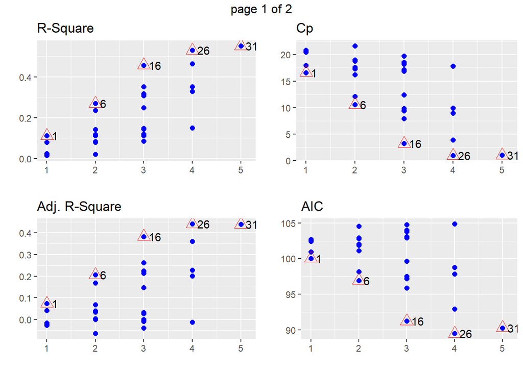

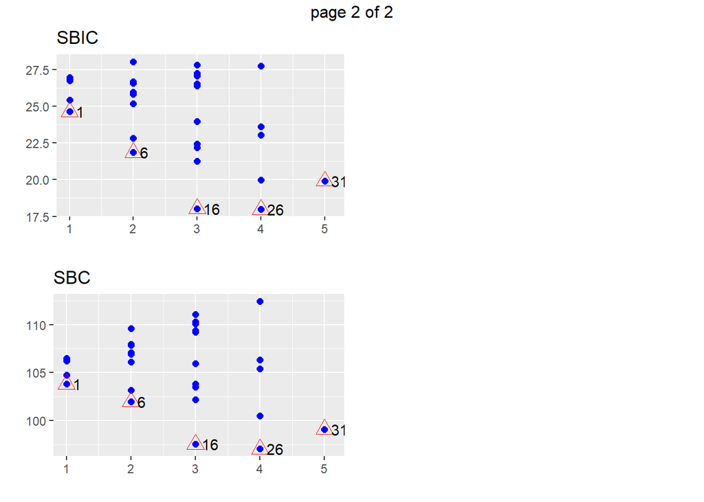

À partir de ces informations, on peut voir que, basé sur la valeur du $R^{2}_{adj}$, le meilleur modèle est celui qui inclut les variables WT2, WT9, HT9 et ST9 (on laisse tomber HT2). On peut toutefois voir que le modèle complet a un meilleur $R^{2}$ que notre modèle réduit. On peut confirmer que notre modèle réduit est toutefois le meilleur, il a également le plus faible AIC (89.471) et la plus grande valeur de $R^{2}_{prev}$ (basée sur PRESS) (0.25032). Les graphiques comfirment les mêmes résultats, notre modèle réduit (#26) est le plus addéquat.

On peut maintenant faire notre prédiction:

```
## [1] "Prédiction pour Y"
```

```
##      fit    lwr    upr
## 1 6.5168 3.5355 9.4981
```

Avec notre modèle, on peut prédire qu’un enfant de 9 ans ayant ces caractéristiques aurait un somatotype de 6.5168 à l’âge de 18 ans. L’intervalle de confiance 95% de cette estimé ponctuel est de [3.5355, 9.4981]